# From Jupyter to Substack

This notebook demonstrates the `nb2wb` converter. It covers the three pillars  
of technical writing: prose, mathematics, and code.

## 1 Inline LaTeX → Unicode

Inline expressions like *α* + *β* = *γ* or *E* = mc² are converted  
to Unicode so they render as plain readable text in Substack's editor.

Other examples: the golden ratio *ϕ* = (1+√5)/(2), and Euler's  
identity *e*<sup>*i**π*</sup> + 1 = 0.

## 2 Display Math → Image

Block equations are rendered to crisp PNG images.

The quadratic formula:

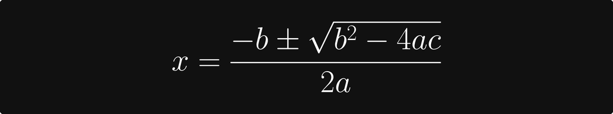

Bayes' theorem:

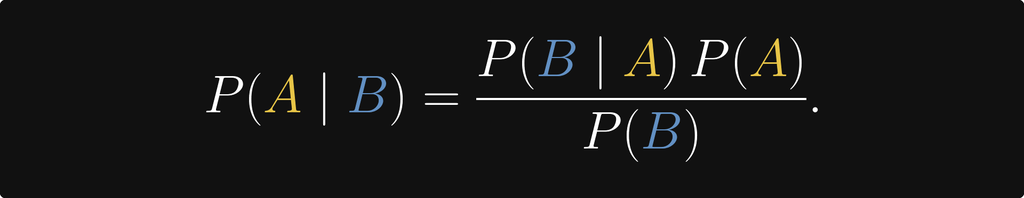

A matrix equation:

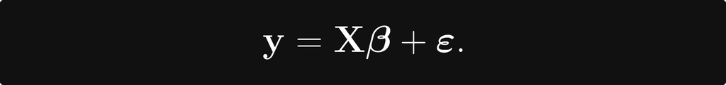

The Basel formula:

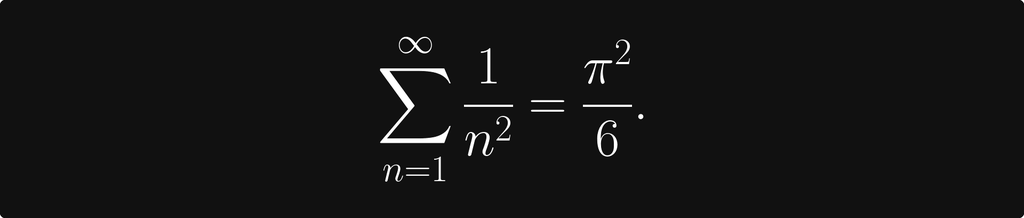

## 3 Code Blocks → Image

Code cells and their outputs are rendered as syntax-highlighted images,  
so formatting and colours are perfectly preserved.

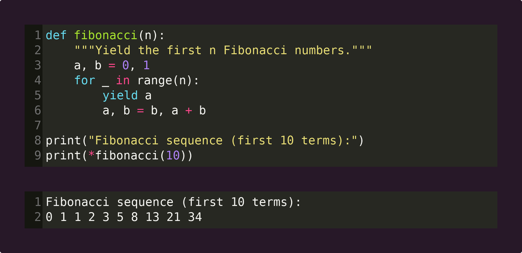

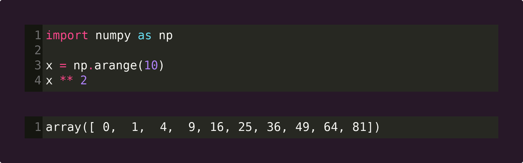

## 4 Mixed: equation in context

The softmax function maps a vector 𝐳 ∈ ℝᴷ to a  
probability distribution:

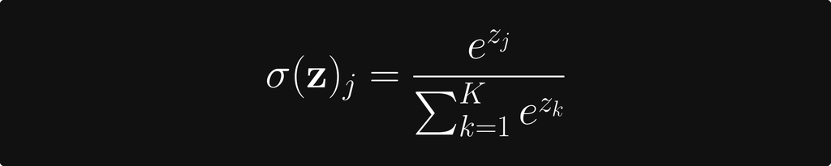

Here *j* = 1, …, *K* indexes the classes. Note that ∑ⱼ *σ*ⱼ = 1  
by construction.

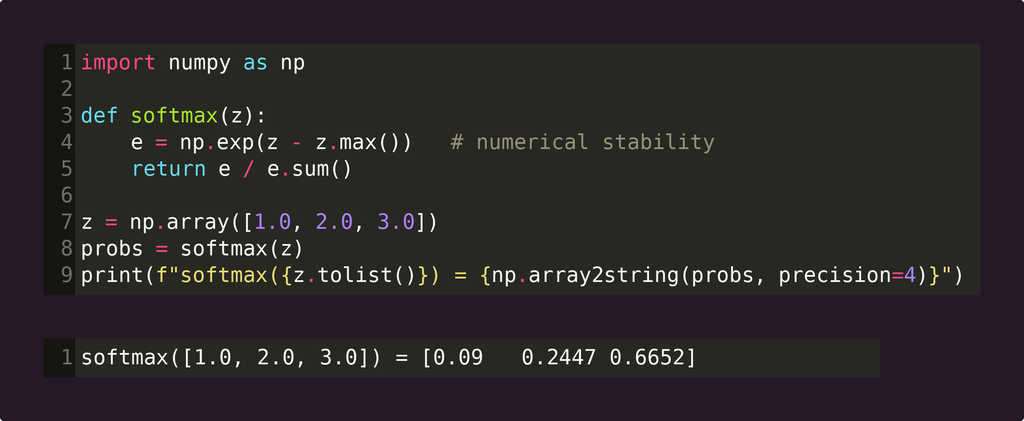

## 5 Figures

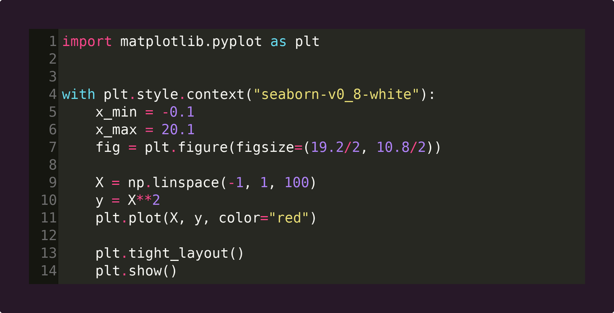

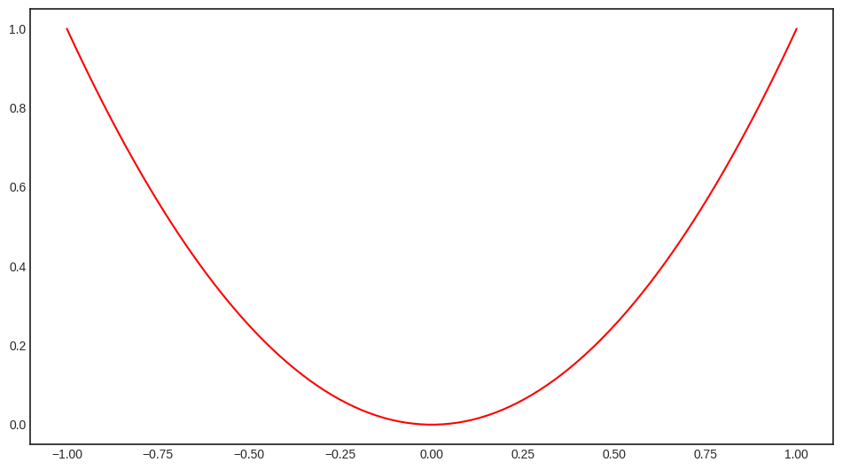

## 6 Cell Tags

Cells can be tagged to control what appears in the output.  
Tags are set via **Edit → Cell Metadata** (or the cell toolbar) in Jupyter.

| Tag | Effect |
| --- | --- |
| `hide-cell` | Entire cell omitted (input + output) |
| `hide-input` | Source code hidden; output shown |
| `hide-output` | Output hidden; source code shown |

The next cell is tagged `hide-input`: only its output is rendered.

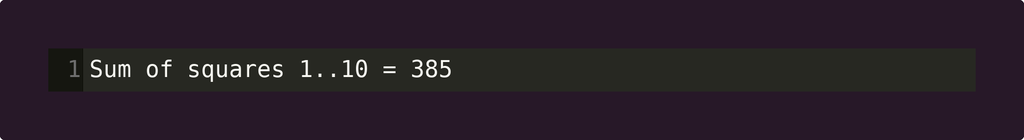

The next cell is tagged `hide-output`: only its source code is rendered.

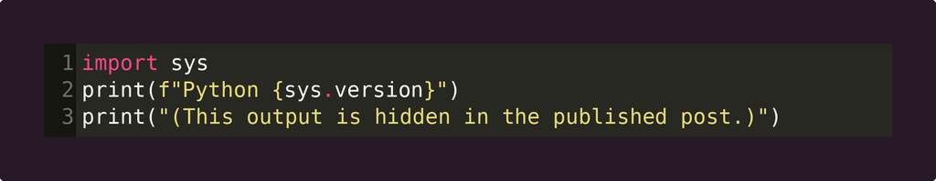

The setup cell at the top of this notebook is tagged `hide-cell` and is invisible in the output.